# Exploratory Data Analysis

Ivan Patel

9/19/2020

# Introduction

Before I can run a multiple linear regression on median housing values, I will explore, visualize, and understand my data. Before building any model, one has to make important decisions about missing values, and how to handle outliers. In my case, I must also check that the data meets all the assumptions of a linear regression. [^1]

I will search answers to my initial questions by visualizing, transforming, and modeling my data. I will also use what I learned to generate new questions about the data. The point of Exploratory Data Analysis is to uncovering the structure of my data, and ensure that it contains good information before making our model.

## Checking the distribution of housing values and median income

Housing value estimate will be my model’s dependent or the response variable. I suspect that its distribution is skewed to the right.

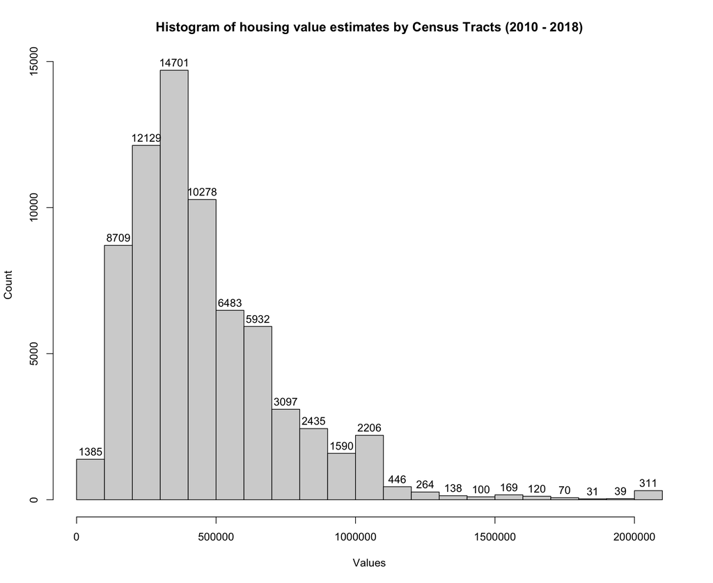

```
##    Min. 1st Qu.  Median    Mean 3rd Qu.    Max.    NA's
##    9999  266400  387900  457260  589600 2000001    1880
```

The histogram does show that housing value estimates is skewed to the right. Given the 75th percentile, about 25% of our observations are census tracts whose housing value estimate exceeds $589,600.

Similarly, median household income by census tracts is also skewed to the right.

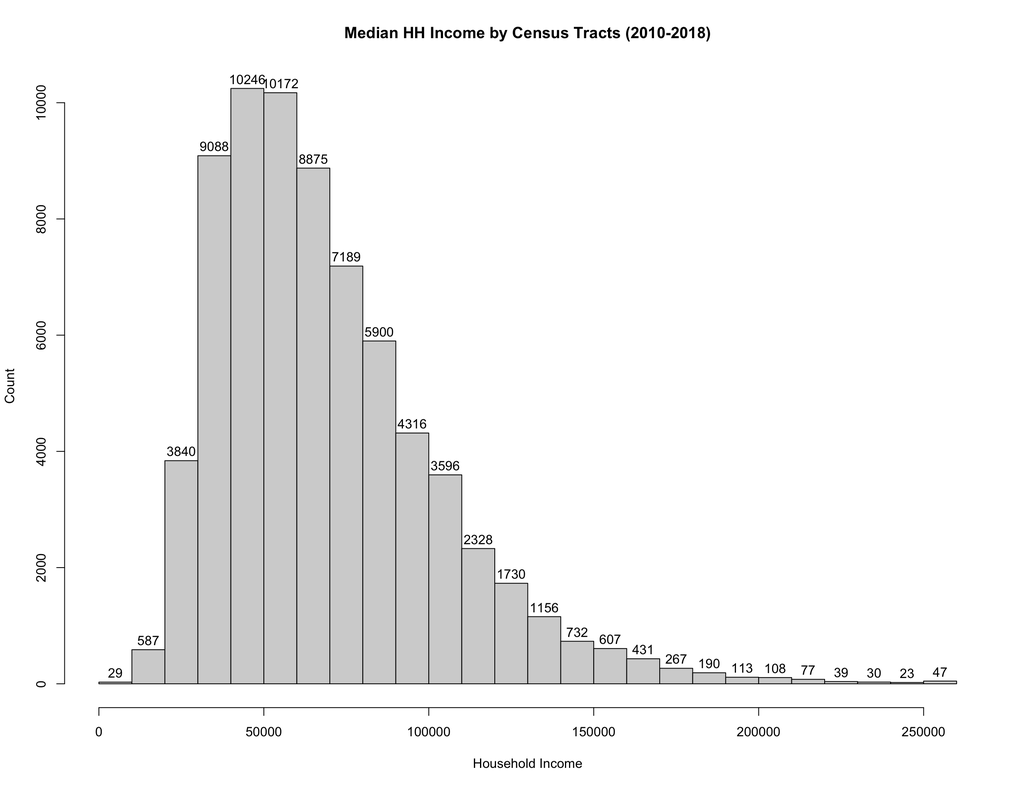

```
##    Min. 1st Qu.  Median    Mean 3rd Qu.    Max.    NA's
##    2499   44100   61875   68706   85844  250001     797
```

Thus, lets reduce the skewness of both variables by taking the natural log of estimates.

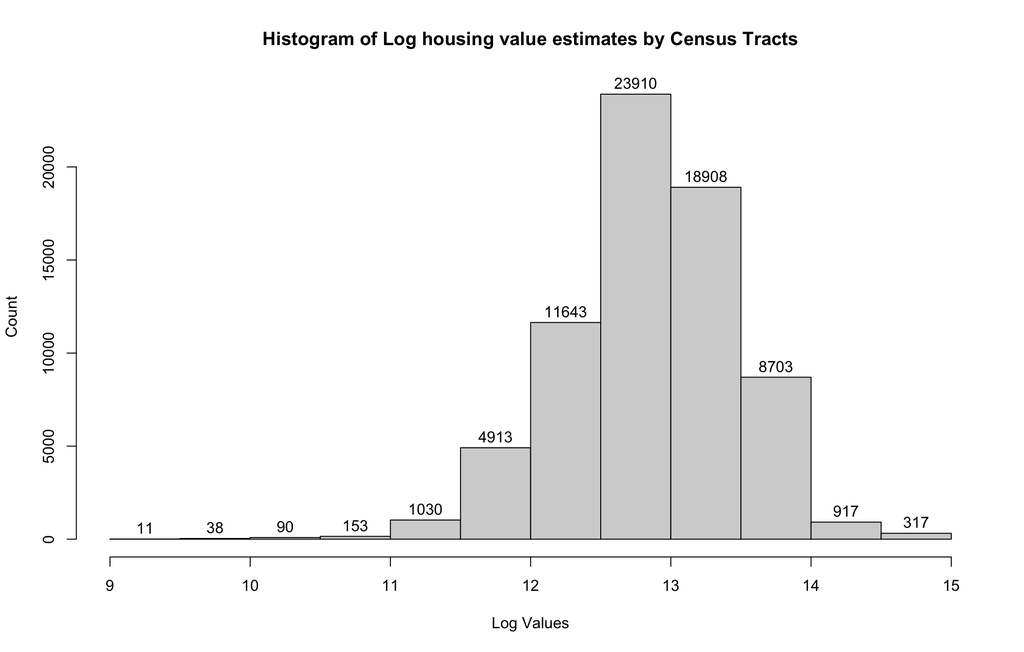

```
##    Min. 1st Qu.  Median    Mean 3rd Qu.    Max.    NA's
##    9.21   12.49   12.87   12.86   13.29   14.51    1880
```

Although the histogram of the log estimate is slightly skewed to the left, the range did decrease significantly

We can do the same log transformation to the median household income by census tract

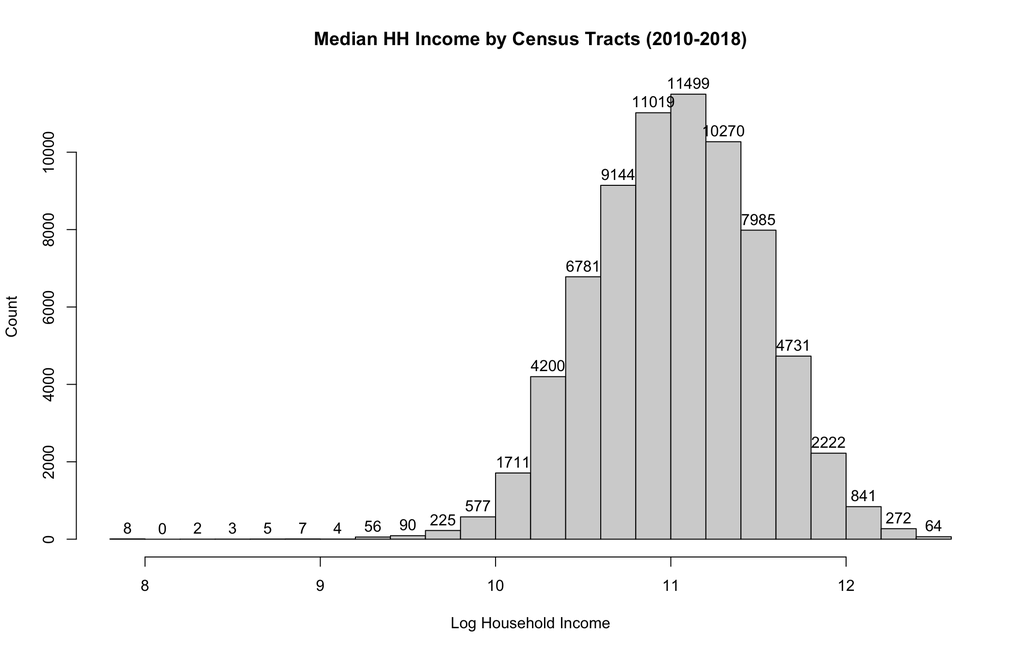

```
##    Min. 1st Qu.  Median    Mean 3rd Qu.    Max.    NA's
##   7.824  10.694  11.033  11.027  11.360  12.429     797
```

We can look at a scatter plot of log median housing values v. log median household income to check linearity. [^2]

## An important thing to note about the scatter plots

The table below shows what was the maximum housing value in each year. From 2010 - 2014, the values have an upper-bound of $1,000,001.

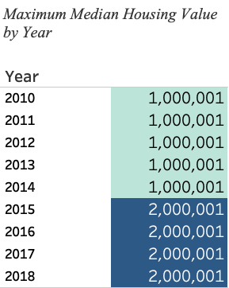

And from 2015 - 2018, the upper-bound is $2,000,001. Similarly, every year’s max median household income by census tract also has an upper-bound of $250,001

## Summary the data, and Creating the final data

```
##  median.housing.value.estimate median.household.income.estimate
##  Min.   :   9999               Min.   :  2499
##  1st Qu.: 266400               1st Qu.: 44100
##  Median : 387900               Median : 61875
##  Mean   : 457260               Mean   : 68706
##  3rd Qu.: 589600               3rd Qu.: 85844
##  Max.   :2000001               Max.   :250001
##  NA's   :1880                  NA's   :797
##  population.estimate total.owner.occupied.housing.units.estimate
##  Min.   :    0       Min.   :   0
##  1st Qu.: 3383       1st Qu.: 472
##  Median : 4489       Median : 794
##  Mean   : 4715       Mean   : 868
##  3rd Qu.: 5760       3rd Qu.:1170
##  Max.   :40616       Max.   :5469
##
##  total.renter.occupied.housing.units.estimate median.age.estimate
##  Min.   :   0.0                               Min.   :14.70
##  1st Qu.: 326.0                               1st Qu.:31.40
##  Median : 606.0                               Median :36.20
##  Mean   : 701.8                               Mean   :37.04
##  3rd Qu.: 961.0                               3rd Qu.:41.80
##  Max.   :7146.0                               Max.   :82.10
##                                               NA's   :432
##  median.number.rooms.estimate median.year.built.estimate
##  Min.   : 1.300               Min.   :   0
##  1st Qu.: 5.300               1st Qu.:1956
##  Median : 5.800               Median :1969
##  Mean   : 5.855               Mean   :1950
##  3rd Qu.: 6.300               3rd Qu.:1981
##  Max.   :10.000               Max.   :2016
##  NA's   :1712                 NA's   :3810
```

The summary shows that we must deal with the NA values. First, let’s check whether or not it is safe to drop the NA values from the median.housing.value.estimate. We have 1880 missing values, and the data consists of 72,513 rows. Therefore, the proportion of rows for which the dependent variable is missing is 2.59%. I also removed missing values from room estimates and income estimates. For some reason, the median.year.built.estimate had two weird values, 0 and 18. Thus, I also removed them too.

Finally, I also added 2 new columns, the natural log of median housing values, and the natural log of median household income.

The final data consists of 67,809 rows, and 22 columns.

[output not shown]

```
## Rows: 67,809
## Columns: 22
## $ GEOID                                        <chr> "06001425103", "06001425…
## $ NAME                                         <chr> "Census Tract 4251.03, A…
## $ median.housing.value.estimate                <dbl> 495900, 398300, 810100, …
## $ median.housing.value.moe                     <dbl> 55568, 80574, 24457, 341…
## $ median.household.income.estimate             <dbl> 71494, 49435, 133221, 10…
## $ median.household.income.moe                  <dbl> 25153, 9746, 15730, 2243…
## $ population.estimate                          <dbl> 2355, 2899, 7058, 3750, …
## $ population.moe                               <dbl> 290, 290, 346, 251, 269,…
## $ total.owner.occupied.housing.units.estimate  <dbl> 458, 454, 2253, 1096, 10…
## $ total.owner.occupied.housing.units.moe       <dbl> 106, 160, 141, 76, 93, 1…
## $ total.renter.occupied.housing.units.estimate <dbl> 748, 1101, 304, 183, 273…
## $ total.renter.occupied.housing.units.moe      <dbl> 145, 186, 104, 74, 93, 1…
## $ median.age.estimate                          <dbl> 33.4, 34.7, 46.5, 44.6, …
## $ median.age.moe                               <dbl> 1.8, 6.5, 1.1, 1.5, 1.8,…
## $ median.number.rooms.estimate                 <dbl> 3.9, 3.9, 6.4, 6.9, 6.2,…
## $ median.number.rooms.moe                      <dbl> 0.3, 0.4, 0.3, 0.4, 0.2,…
## $ median.year.built.estimate                   <dbl> 2003, 1950, 1985, 1959, …
## $ median.year.built.moe                        <dbl> 2, 36, 2, 2, 2, 7, 2, 14…
## $ year                                         <int> 2010, 2010, 2010, 2010, …
## $ geometry                                     <MULTIPOLYGON [°]> MULTIPOLYGO…
## $ log_median.housing.value.estimate            <dbl> 13.11413, 12.89496, 13.6…
## $ log_median.household.income.estimate         <dbl> 11.17737, 10.80841, 11.7…
```

#### Correlation Matrix

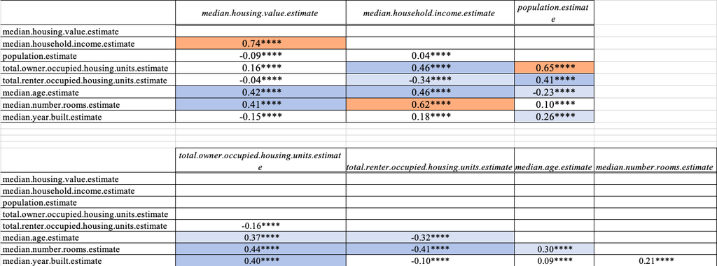

### Multiple Linear Regression

```r
library(gt)
model_data <- ca_data_2 %>% st_drop_geometry() %>%
  select(contains('estimate'), -median.household.income.estimate, -median.housing.value.estimate)

model <- lm(data = model_data, log_median.housing.value.estimate ~ .)
get_regression_table(model) %>% gt()
```

| term | estimate | std_error | statistic | p_value | lower_ci | upper_ci |
| --- | --- | --- | --- | --- | --- | --- |
| intercept | 18.981 | 0.176 | 107.763 | 0.000 | 18.636 | 19.327 |
| population.estimate | 0.000 | 0.000 | 2.085 | 0.037 | 0.000 | 0.000 |
| total.owner.occupied.housing.units.estimate | 0.000 | 0.000 | -38.210 | 0.000 | 0.000 | 0.000 |
| total.renter.occupied.housing.units.estimate | 0.000 | 0.000 | 81.002 | 0.000 | 0.000 | 0.000 |
| median.age.estimate | 0.017 | 0.000 | 62.008 | 0.000 | 0.016 | 0.017 |
| median.number.rooms.estimate | 0.086 | 0.002 | 39.740 | 0.000 | 0.082 | 0.090 |
| median.year.built.estimate | -0.010 | 0.000 | -108.710 | 0.000 | -0.010 | -0.009 |
| log_median.household.income.estimate | 1.039 | 0.004 | 250.194 | 0.000 | 1.031 | 1.047 |

[^1]: [Assumptions of Linear regression](http://r-statistics.co/Assumptions-of-Linear-Regression.html)
[^2]: [Scatter Plot Dashboard](https://public.tableau.com/profile/ivan.patel#!/vizhome/HoseholdValuevHouseholdIncomeforCACensusTracts2010-2018/Dashboard1?publish=yes). There are two charts on this dashboard. The top one shows the scatter plot of log housing values v log household income for a given year between 2010 and 2018. The bottom chart is a plot of just housing values v household income for a given year.